# Problem Set 3

Author

Tiffany Wu

## Github Repo Link to Problem Set 3:

https://github.com/tiffany-wu/Stats506/tree/main/PS3

## Problem 1 - Vision

This problem will require you to learn things we have not covered. Use the R help, or online resources, to figure out the appropriate command(s). Use citation as necessary.

For the “nice tables”, use a package such as kable or stargazer (or find another package) to generate HTML/LaTeX tables for inclusion. The results should be clearly labeled, rounded appropriately, and easily readable.

```r
# Load necessary libraries
library(knitr)
library(kableExtra)
library(stargazer)
library(gtsummary)
library(tidyverse)
library(haven) # to read in .XPT files
```

### a. Download the file VIX_D from this location, and determine how to read it into R. Then download the file DEMO_D from this location. Note that each page contains a link to a documentation file for that data set. Merge the two files to create a single data.frame, using the SEQN variable for merging. Keep only records which matched. Print out your total sample size, showing that it is now 6,980.

```r
# Read the .XPT files -- these are SAS transport files
vix <- read_xpt("VIX_D.xpt")
demo <- read_xpt("DEMO_D.xpt")

# Merge, using SEQN as the key
merged_data <- merge(vix, demo, by = "SEQN")

# Check the total sample size
nrow(merged_data) # Should be 6,980
```

```
[1] 6980
```

### b. Without fitting any models, estimate the proportion of respondents within each 10-year age bracket (e.g. 0-9, 10-19, 20-29, etc) who wear glasses/contact lenses for distance vision. Produce a nice table with the results.

Based on the codebook documents:

- RIDAGEYR is age in years, which is what we would want to be able to put respondents in 10-year age brackets. It includes both males and females 12-150 years, but 85 years is the oldest.
- VIQ220 is the question for: Glasses/contact lenses for distance vision? 1 is yes, 2 is no, 9 is don’t know, NA is missing. For coding who wears glasses/contact lenses, we code 1 as yes and 2 and 9 as “no” (since not knowing means you might not wear glasses/contact lenses).

```r
# Create age groups
age_groups <- merged_data %>%
  dplyr::select(id = SEQN,
         age = RIDAGEYR,
         wears_glasses = VIQ220) %>%
  mutate(age_group = case_when(
    age >= 0 & age < 10 ~ "0-9",
    age >= 10 & age < 20 ~ "10-19",
    age >= 20 & age < 30 ~ "20-29",
    age >= 30 & age < 40 ~ "30-39",
    age >= 40 & age < 50 ~ "40-49",
    age >= 50 & age < 60 ~ "50-59",
    age >= 60 & age < 70 ~ "60-69",
    age >= 70 & age < 80 ~ "70-79",
    age >= 80 & age < 90 ~ "80-89",
    TRUE ~ NA_character_  # For ages outside the specified range
  )) %>%
  drop_na(wears_glasses) %>%
  mutate(wears_glasses = as.factor(wears_glasses))

# Check to see that everyone is grouped
# psych::describe(age_groups) # Comment out to make final output cleaner

# Convert wears_glasses variable into a binary outcome
# 1 = wears glasses, 2 = doesn't wear
age_groups_bin <- age_groups %>%
  mutate(wears_glasses = ifelse(wears_glasses == 1, 1, 0))

# Summarize the proportion of glasses wearers by age group
proportion_wear_glasses <- age_groups_bin %>%
  group_by(age_group) %>%
  summarize(proportion_wear_glasses = round(mean(wears_glasses, na.rm = TRUE), 2),
            num_glasses = sum(wears_glasses),
            total = sum(!is.na(wears_glasses)))  # Count of respondents in each group, check that it sums to 6547

# Display the result
# print(proportion_wear_glasses) # Comment out for final output

# Rename columns in the proportion_wear_glasses data frame for stargazer table
proportion_wear_glasses_renamed <- proportion_wear_glasses %>%
  rename(
    "Age group" = age_group,
    "Proportion wearing glasses" = proportion_wear_glasses,
    "# Glass wearers" = num_glasses,
    "Total count" = total
  )

# Convert the renamed data frame to a matrix to get rid of numbers on LHS (Source: ChatGPT)
proportion_wear_glasses_matrix <- as.matrix(proportion_wear_glasses_renamed)

# Create a pretty table using stargazer
stargazer(proportion_wear_glasses_matrix,
       #   type = "text", Switch to HTML when render
          type = "html",
          summary = FALSE,
          title = "Proportion of Glasses Wearers by Age Group",
          digits = 2,
          font.size = "large")
```

**Proportion of Glasses Wearers by Age Group**

| Age group | Proportion wearing glasses | # Glass wearers | Total count |
| --- | --- | --- | --- |
| 10-19 | 0.32 | 670 | 2088 |
| 20-29 | 0.33 | 306 | 939 |
| 30-39 | 0.36 | 269 | 750 |
| 40-49 | 0.37 | 286 | 773 |
| 50-59 | 0.55 | 335 | 609 |
| 60-69 | 0.62 | 392 | 630 |
| 70-79 | 0.67 | 299 | 447 |
| 80-89 | 0.67 | 208 | 311 |

### c. Fit three logistic regression models predicting whether a respondent wears glasses/contact lenses for distance vision. Predictors:

#### 1. age

For this regression, we see that a one year increase in age is positively associated (and statistically significant) with the likelihood that the respondent wears glasses/contact lenses.

#### 2. age, race, gender

Even after controlling for race and gender, we see that the relationship between age and wearing glasses/contact lenses is still positive and statistically significant.

#### 3. age, race, gender, Poverty Income ratio

This relationship remains positive and statistically significant after adding the poverty income ratio as a control variable.

```r
# Make overall df for logistic regressions without taking out age group NAs
log_reg_df <- merged_data %>%
  dplyr::select(id = SEQN,
         age = RIDAGEYR,
         wears_glasses = VIQ220,
         gender = RIAGENDR,
         race = RIDRETH1,
         poverty_income_ratio = INDFMPIR
         ) %>%
  mutate(wears_glasses = ifelse(wears_glasses == 1, 1, 0)) %>%
  mutate(gender = ifelse(gender == 1, "male", "female")) %>% # coding gender value
  mutate(age_group = case_when(
    age >= 0 & age < 10 ~ "0-9",
    age >= 10 & age < 20 ~ "10-19",
    age >= 20 & age < 30 ~ "20-29",
    age >= 30 & age < 40 ~ "30-39",
    age >= 40 & age < 50 ~ "40-49",
    age >= 50 & age < 60 ~ "50-59",
    age >= 60 & age < 70 ~ "60-69",
    age >= 70 & age < 80 ~ "70-79",
    age >= 85 & age < 90 ~ "80-89",
    TRUE ~ NA_character_  # For ages outside the specified range
  )) %>%
  mutate(race = as.factor(race),
         gender = as.factor(gender))

# Fit Model 1: age as predictor
model1 <- glm(wears_glasses ~ age,
              data = log_reg_df,
              family = binomial)
summary(model1)
```

```
Call:
glm(formula = wears_glasses ~ age, family = binomial, data = log_reg_df)

Coefficients:
             Estimate Std. Error z value Pr(>|z|)
(Intercept) -1.261893   0.053447  -23.61   <2e-16 ***
age          0.024684   0.001206   20.48   <2e-16 ***
---
Signif. codes:  0 '***' 0.001 '**' 0.01 '*' 0.05 '.' 0.1 ' ' 1

(Dispersion parameter for binomial family taken to be 1)

    Null deviance: 8917.4  on 6546  degrees of freedom
Residual deviance: 8473.7  on 6545  degrees of freedom
  (433 observations deleted due to missingness)
AIC: 8477.7

Number of Fisher Scoring iterations: 4
```

```r
# Fit Model 2: age, race, and gender as predictors
# Ensure that `race` and `gender` variables are in the dataset.
model2 <- glm(wears_glasses ~ age + race + gender,
              data = log_reg_df,
              family = binomial)
summary(model2)
```

```
Call:
glm(formula = wears_glasses ~ age + race + gender, family = binomial,
    data = log_reg_df)

Coefficients:
             Estimate Std. Error z value Pr(>|z|)
(Intercept) -1.336493   0.072857 -18.344  < 2e-16 ***
age          0.022587   0.001262  17.892  < 2e-16 ***
race2        0.157336   0.164280   0.958 0.338199
race3        0.668994   0.070010   9.556  < 2e-16 ***
race4        0.262837   0.076574   3.432 0.000598 ***
race5        0.652075   0.135403   4.816 1.47e-06 ***
gendermale  -0.501051   0.053005  -9.453  < 2e-16 ***
---
Signif. codes:  0 '***' 0.001 '**' 0.01 '*' 0.05 '.' 0.1 ' ' 1

(Dispersion parameter for binomial family taken to be 1)

    Null deviance: 8917.4  on 6546  degrees of freedom
Residual deviance: 8275.9  on 6540  degrees of freedom
  (433 observations deleted due to missingness)
AIC: 8289.9

Number of Fisher Scoring iterations: 4
```

```r
# Fit Model 3: age, race, gender, and poverty income ratio as predictors
# Ensure `poverty_income_ratio` is included in the dataset.
model3 <- glm(wears_glasses ~ age + race + gender + poverty_income_ratio,
              data = log_reg_df,
              family = binomial)
summary(model3)
```

```
Call:
glm(formula = wears_glasses ~ age + race + gender + poverty_income_ratio,
    family = binomial, data = log_reg_df)

Coefficients:
                      Estimate Std. Error z value Pr(>|z|)
(Intercept)          -1.501941   0.082161 -18.280  < 2e-16 ***
age                   0.022202   0.001295  17.146  < 2e-16 ***
race2                 0.117483   0.168257   0.698 0.485030
race3                 0.502239   0.075116   6.686 2.29e-11 ***
race4                 0.208817   0.079205   2.636 0.008379 **
race5                 0.534345   0.140139   3.813 0.000137 ***
gendermale           -0.515109   0.054298  -9.487  < 2e-16 ***
poverty_income_ratio  0.113427   0.017699   6.409 1.47e-10 ***
---
Signif. codes:  0 '***' 0.001 '**' 0.01 '*' 0.05 '.' 0.1 ' ' 1

(Dispersion parameter for binomial family taken to be 1)

    Null deviance: 8521.3  on 6248  degrees of freedom
Residual deviance: 7896.1  on 6241  degrees of freedom
  (731 observations deleted due to missingness)
AIC: 7912.1

Number of Fisher Scoring iterations: 4
```

### Produce a table presenting the estimated odds ratios for the coefficients in each model, along with the sample size for the model, the pseudo-R2, and AIC values.

Below we have a table of the above information, using the stargazer library.

```r
# Using stargazer to create table--stargazer needs psc1 for pseudo_R2 according to ChatGPT. Also tried keep.stat, but it doesn't work, so we need to manually add this.
library(pscl)
# Calculate pseudo-R² for each model
pseudo_r2_model1 <- pscl::pR2(model1)["McFadden"]
```

fitting null model for pseudo-r2

```r
pseudo_r2_model2 <- pscl::pR2(model2)["McFadden"]
```

fitting null model for pseudo-r2

```r
pseudo_r2_model3 <- pscl::pR2(model3)["McFadden"]
```

fitting null model for pseudo-r2

```r
# Try first
stargazer(model1, model2, model3,
    #      type = "text", # to view in RStudio-- comment out when actually rendering
          type = "html",
          digits = 3,
          apply.coef = exp, # Exponentiate coefs to get odds ratios
          keep.stat = c("rsq", "adj.rsq", "ll", "aic", "n"),
          add.lines = list(
            c("Pseudo R²", round(pseudo_r2_model1, 3), round(pseudo_r2_model2, 3), round(pseudo_r2_model3, 3))
          ),
          title = "Logistic Regression Models Predicting Glasses Use",
          covariate.labels = c("Age", "Other Hispanic", "Non-Hispanic White", "Non-Hispanic Black", "Non-Hispanic Other or Multiracial", "Male", "Poverty Income Ratio"),
          dep.var.labels = "Wears Glasses (Odds Ratio)")
```

**Logistic Regression Models Predicting Glasses Use**

|  | *Dependent variable:* |  |  |
| --- | --- | --- | --- |
|  | Wears Glasses (Odds Ratio) |  |  |
|  | (1) | (2) | (3) |
| Age | 1.025*** | 1.023*** | 1.022*** |
|  | (0.001) | (0.001) | (0.001) |
| Other Hispanic |  | 1.170*** | 1.125*** |
|  |  | (0.164) | (0.168) |
| Non-Hispanic White |  | 1.952*** | 1.652*** |
|  |  | (0.070) | (0.075) |
| Non-Hispanic Black |  | 1.301*** | 1.232*** |
|  |  | (0.077) | (0.079) |
| Non-Hispanic Other or Multiracial |  | 1.920*** | 1.706*** |
|  |  | (0.135) | (0.140) |
| Male |  | 0.606*** | 0.597*** |
|  |  | (0.053) | (0.054) |
| Poverty Income Ratio |  |  | 1.120*** |
|  |  |  | (0.018) |
| Constant | 0.283*** | 0.263*** | 0.223*** |
|  | (0.053) | (0.073) | (0.082) |
| Pseudo R² | 0.05 | 0.072 | 0.073 |
| Observations | 6,547 | 6,547 | 6,249 |
| Log Likelihood | -4,236.840 | -4,137.962 | -3,948.039 |
| Akaike Inf. Crit. | 8,477.679 | 8,289.925 | 7,912.077 |
| *Note:* | *p<0.1; **p<0.05;*** p<0.01 |  |  |

### d. From the third model from the previous part, test whether the odds of men and women being wears of glasses/contact lenses for distance vision differs. Test whether the proportion of wearers of glasses/contact lenses for distance vision differs between men and women. Include the results of the each test and their interpretation.

We use the emmeans library to test whether the odds of mean and women for wearing glasses/contact lenses differs. First, we do `pairs(emmeans(model3, ~gender))` to test the difference in log-odds. We see the estimate is 0.515 and statistically significant, which means that the odds are statistically significantly different between men and women. This matches our coefficient from model3 above (although it is flipped since this contrast is female-male instead of male-female). Both interpretations are consistent though– Males have statistically significantly lower odds of wearing glasses/contact lenses compared to females. Said differently, females have statistically significantly higher odds of wearing glasses/contact lenses compared to males.

We can also use the emmeans library to test the proportion differences, using `pairs(emmeans(model3, ~gender, type = "response")).` The odds ratio for female/male is 1.67 and statistically significant, which means that the odds of females wearing glasses/contact lenses are 67% higher than the odds for males. Inverting the odds ratio (1/1.67) aligns with the earlier results from the above `stargazer` table showing that males have around 40% lower odds of wearing glasses compared to females – both odds ratios are the same, just the base comparison group for interpretation changed.

```r
library(emmeans)
# Are the log-odds stat. sig?
pairs(emmeans(model3, ~gender))
```

```
 contrast      estimate     SE  df z.ratio p.value
 female - male    0.515 0.0543 Inf   9.487  <.0001

Results are averaged over the levels of: race
Results are given on the log odds ratio (not the response) scale.
```

```r
# Are the proportions stat. sig?
pairs(emmeans(model3, ~gender, type = "response")) # type = "response" gets you odds ratio
```

```
 contrast      odds.ratio     SE  df null z.ratio p.value
 female / male       1.67 0.0909 Inf    1   9.487  <.0001

Results are averaged over the levels of: race
Tests are performed on the log odds ratio scale
```

```r
# Compare with stargazer odds ratio output
1/1.67 # Should give us around 0.597 to match the stargazer table in the previous question. It does.
```

```
[1] 0.5988024
```

## Problem 2 - Sakila

Load the “sakila” database discussed in class into SQLite. It can be downloaded from https://github.com/bradleygrant/sakila-sqlite3.

```r
# Load in necessary libraries
library(DBI) # necessary evil. Holds SQL to R, handles backend so they can talk to each other
library(RSQLite)

# dbConnect: 2 arguments. What kind of connection/what tool to use? What database (usually it's a pathway to the server the data is stored on)?
sakila <- dbConnect(SQLite(), "sakila_master.db")

# Trick to not type dbGetQuery over and over again
# Not a great function because you're calling lahman from the global environment, but it's helpful.
gg <- function(query){
  dbGetQuery(sakila, query)
}

# What tables are available?
dbListTables(sakila)
```

```
 [1] "actor"                  "address"                "category"
 [4] "city"                   "country"                "customer"
 [7] "customer_list"          "film"                   "film_actor"
[10] "film_category"          "film_list"              "film_text"
[13] "inventory"              "language"               "payment"
[16] "rental"                 "sales_by_film_category" "sales_by_store"
[19] "staff"                  "staff_list"             "store"
```

For these problems, do not use any of the tables whose names end in _list.

### a. What year is the oldest movie from, and how many movies were released in that year? Answer this with a single SQL query.

The oldest movie is from 2006. 1000 movies were release that year. Every movie in this fake database was released in the same year.

```r
# What variables are inside the "film" table?
dbListFields(sakila, "film")
```

```
 [1] "film_id"              "title"                "description"
 [4] "release_year"         "language_id"          "original_language_id"
 [7] "rental_duration"      "rental_rate"          "length"
[10] "replacement_cost"     "rating"               "special_features"
[13] "last_update"
```

```r
# SQL query
#gg("SELECT title, release_year # First, make sure what you're seeing is real
#   FROM film
#   WHERE release_year = (SELECT MIN(release_year) FROM film)")

# Single SQL Query
gg("SELECT count(title), release_year
   FROM film
   GROUP BY release_year")
```

```
  count(title) release_year
1         1000         2006
```

### For each of the following questions, solve them in two ways: First, use SQL query or queries to extract the appropriate table(s), then use regular R operations on those data.frames to answer the question. Second, use a single SQL query to answer the question.

### b. What genre of movie is the least common in the data, and how many movies are of this genre?

The genre with the least common data is Music, which has 51 movies.

```r
# Extract information on film genres
film_category_query <- "
  SELECT category.name AS genre, COUNT(film.film_id) AS count
  FROM film
  JOIN film_category ON film.film_id = film_category.film_id
  JOIN category ON film_category.category_id = category.category_id
  GROUP BY category.name;
"
gg(film_category_query)
```

```
         genre count
1       Action    64
2    Animation    66
3     Children    60
4     Classics    57
5       Comedy    58
6  Documentary    68
7        Drama    62
8       Family    69
9      Foreign    73
10       Games    61
11      Horror    56
12       Music    51
13         New    63
14      Sci-Fi    61
15      Sports    74
16      Travel    57
```

```r
# Get the result as a data.frame
film_category_data <- gg(film_category_query)

# Find the least common genre and its count using R operations
least_common_genre <- film_category_data[which.min(film_category_data$count), ]
print(least_common_genre)
```

```
   genre count
12 Music    51
```

```r
# Use SQL to answer the question:
gg("SELECT category.name AS genre, COUNT(film.film_id) AS count
  FROM film
  JOIN film_category ON film.film_id = film_category.film_id
  JOIN category ON film_category.category_id = category.category_id
  GROUP BY category.name
  ORDER BY count ASC
  LIMIT 1"
)
```

```
  genre count
1 Music    51
```

### c. Identify which country or countries have exactly 13 customers.

Argentina and Nigeria have exactly 13 customers.

```r
# Extract country and customer count information
customer_country_query <-
  "SELECT country.country, COUNT(customer.customer_id) AS count
  FROM customer
  JOIN address ON customer.address_id = address.address_id
  JOIN city ON address.city_id = city.city_id
  JOIN country ON city.country_id = country.country_id
  GROUP BY country.country"

gg(customer_country_query)
```

```
                                  country count
1                             Afghanistan     1
2                                 Algeria     3
3                          American Samoa     1
4                                  Angola     2
5                                Anguilla     1
6                               Argentina    13
7                                 Armenia     1
8                                 Austria     3
9                              Azerbaijan     2
10                                Bahrain     1
11                             Bangladesh     3
12                                Belarus     2
13                                Bolivia     2
14                                 Brazil    28
```

[output cut: 94 more lines]

```r
# Get the result as a data.frame
customer_country_data <- gg(customer_country_query)

# Find countries with exactly 13 customers using R operations
countries_with_13_customers <- customer_country_data[customer_country_data$count == 13, ]

print(countries_with_13_customers)
```

```
     country count
6  Argentina    13
68   Nigeria    13
```

```r
# Use SQL
gg("SELECT country.country, COUNT(customer.customer_id) AS count
  FROM customer
  JOIN address ON customer.address_id = address.address_id
  JOIN city ON address.city_id = city.city_id
  JOIN country ON city.country_id = country.country_id
  GROUP BY country.country
  HAVING count = 13")
```

```
    country count
1 Argentina    13
2   Nigeria    13
```

## Problem 3 - US Records

Download the “US - 500 Records” data from https://www.briandunning.com/sample-data/ and import it into R. This is entirely fake data - use it to answer the following questions.

```r
# Read in data
library(readr)
us_500 <- read_csv("us-500.csv")
```

### a. What proportion of email addresses are hosted at a domain with TLD “.com”? (in the email, “angrycat@freemail.org”, “freemail.org” is the domain, and “.org” is the TLD (top-level domain).)

73.2% of the email addresses are hosted at a domain with TLD “.com”.

To get this proportion, we used the following regex to first extract the domain and TLD– (?<=@)[^.]+\.(.+), where:

- (?<=@): A positive lookbehind to ensure that we are capturing the part after the ‘@’ symbol.
- [^.]+: Matches any characters until the first period, which represents the domain.
- \.(.+): Captures the TLD part after the dot.

Then, we used filter(str_detect(tld, “\.com$”)) to filter out only the “.com” TLDs:

- str_detect(): Checks if the TLD ends with .com.
- \.com$: Matches .com at the end of the string.

```r
# Load necessary library for string manipulation
library(stringr)

# Extract the domain and TLD from email addresses using a regular expression
# (?<=@)[^.]+\\.(.+) matches the part of the email after '@' and captures the TLD
us_500_2 <- us_500 %>%
  mutate(tld = str_extract(email, "(?<=@)[^.]+\\.(.+)"))  # Extracting the domain and TLD

# Filter out only ".com" TLDs
com_emails <- us_500_2 %>%
  filter(str_detect(tld, "\\.com$"))

# Calculate the proportion of ".com" email addresses
nrow(com_emails) / nrow(us_500_2)
```

```
[1] 0.732
```

### b. What proportion of email addresses have at least one non alphanumeric character in them? (Excluding the required “@” and “.” found in every email address.)

24.8% of the email addresses have at least 1 non alphanumeric character.

To do this, we used str_detect(email, “[^a-zA-Z0-9@.]”)) to identify the non alphanumeric characters, excluding “@” and “.”:

- [^...] is a negated character class that matches any character not listed within the brackets.
- a-zA-Z0-9 matches letters (both upper and lower case) and digits.
- 1. matches the required @ and . characters in email addresses.
- [^a-zA-Z0-9@.] matches any character that is not a letter, digit, @, or ., which indicates a non-alphanumeric character.

```r
# Get rid of alphabet, numbers, @, and . in the email column
us_500_3 <- us_500 %>%
  mutate(has_special_char = str_detect(email, "[^a-zA-Z0-9@.]"))

# Filter out rows where 'has_special_char' is TRUE
special_char_emails <- us_500_3 %>%
  filter(has_special_char)

# Calculate the proportion of email addresses with at least one non-alphanumeric character
nrow(special_char_emails) / nrow(us_500)
```

```
[1] 0.248
```

### c. What are the top 5 most common area codes amongst all phone numbers? (The area code is the first three digits of a standard 10-digit telephone number.)

The top 5 most common area codes are: 973, 212, 215, 410, and 201.

```r
# Extract the area code from the phone numbers
us_500_phone <- us_500 %>%
  mutate(area_code = str_extract(phone1, "\\d{3}"))

# Count how many of each area code and sort
us_500_phone %>%
  count(area_code, sort = TRUE) %>%
  slice_head(n = 5)
```

```
# A tibble: 5 × 2
  area_code     n
  <chr>     <int>
1 973          18
2 212          14
3 215          14
4 410          14
5 201          12
```

### d. Produce a histogram of the log of the apartment numbers for all addresses. (You may assume any number at the end of the an address is an apartment number.)

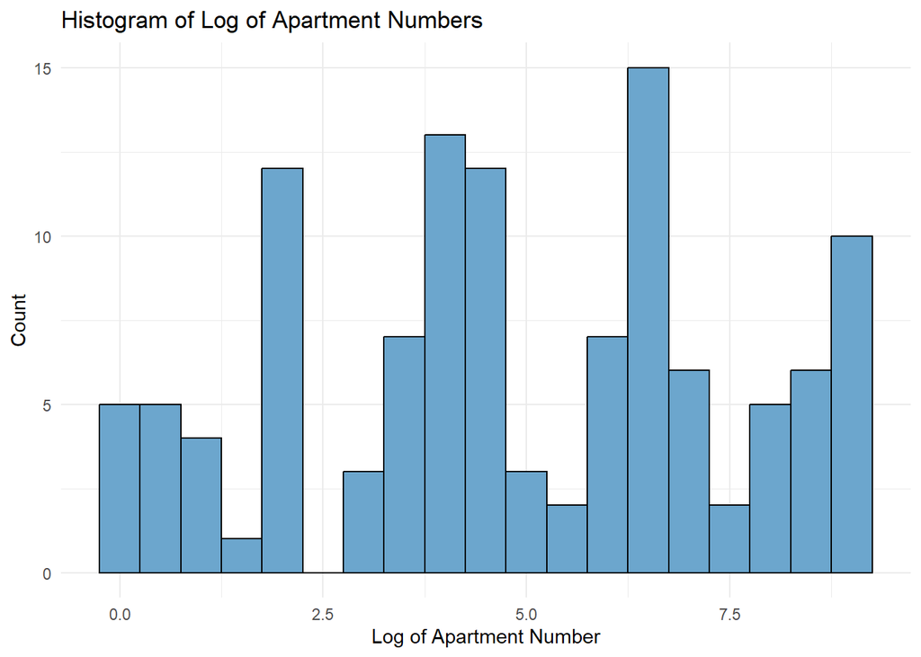

```r
# Extract the last number from address
apt_nums <-  us_500 %>%
  mutate(apartment_number = as.numeric(str_extract(address, "\\d+$")))

# Calculate the logarithm of apartment numbers, excluding missing
apt_nums <- apt_nums %>%
  filter(!is.na(apartment_number)) %>%  # Remove NAs
  mutate(log_apartment_number = log(apartment_number))

# Create the histogram
ggplot(apt_nums, aes(x = log_apartment_number)) +
  geom_histogram(binwidth = 0.5, fill = "skyblue3", color = "black") +
  labs(title = "Histogram of Log of Apartment Numbers",
       x = "Log of Apartment Number",
       y = "Count") +
  theme_minimal()
```

### e. Benford’s law is an observation about the distribution of the leading digit of real numerical data. Examine whether the apartment numbers appear to follow Benford’s law. Do you think the apartment numbers would pass as real data?

According ChatGPT, Benford’s Law refers to the phenomenon that, in many naturally occurring datasets, the leading digit 1 appears about 30% of the time, and the probability decreases for larger digits. Benford’s Law is also known as the first-digit law. In other words, the leading digit is more likely to be a smaller number than a bigger one.

We generate the expected Benford’s Law proportions using the equation given to us by ChatGPT and compare it below with the frequency of leading digits in our us_500 dataset. In the us_500 dataset, all leading digits have similar frequences of appearing, which means that the aparment numbers **would not pass** as real data according to Benford’s Law.

```r
# Extract the leading digit from the apartment numbers
leading <- apt_nums %>%
  mutate(leading_digit = as.numeric(str_extract(as.character(apartment_number), "^\\d")))

# Calculate frequency of each leading digit
leading_digit_freq <- leading %>%
  count(leading_digit) %>%
  mutate(us_500_proportion = n / sum(n))

# Compare with Benford's Law
# Calculate the expected Benford's Law proportions
benford_probs <- tibble(
  leading_digit = 1:9,
  benford_proportion = log10((1 + leading_digit) / leading_digit)
)

# Merge with observed proportions for comparison
comparison <- left_join(leading_digit_freq, benford_probs, by = "leading_digit")
print(comparison)
```

```
# A tibble: 9 × 4
  leading_digit     n us_500_proportion benford_proportion
          <dbl> <int>             <dbl>              <dbl>
1             1    15            0.127              0.301
2             2    13            0.110              0.176
3             3    12            0.102              0.125
4             4    12            0.102              0.0969
5             5    15            0.127              0.0792
6             6    11            0.0932             0.0669
7             7    12            0.102              0.0580
8             8    11            0.0932             0.0512
9             9    17            0.144              0.0458
```